# Storm Events on Population Health and Economic Consequences

– An Analysis of the NOAA Storm Database (1950-2011), United States

by David Song

2019-09-14

# Synopsis

This is John Hopkins University Data Science Series - Reproducible research, Course Project 2

This project involves exploring the U.S. National Oceanic and Atmospheric Administration’s (NOAA) storm database. This database tracks characteristics of major storms and weather events in the United States, including when and where they occur, as well as estimates of any fatalities, injuries, and property damage.

In this study, we analysis fatalities and injuries, property and crop damages from various storm events. We found that, tornado causes the highest fatalities and injuries, over weighted other factors. Surprisingly, overheat is the second largest fatality factor, which almost doubled the third largest factor fatality flood. Flood is the highest cause for property damages, and drought is the biggest cause for crop losses.

# Data

## Resources

Storm event Data which is used in this analysis study can be found at [Storm Data [47Mb]](https://d396qusza40orc.cloudfront.net/repdata%2Fdata%2FStormData.csv.bz2)

There is also some documentation of the database available. Here you will find how some of the variables are constructed/defined.

- National Weather Service [Storm Data Documentation](https://d396qusza40orc.cloudfront.net/repdata%2Fpeer2_doc%2Fpd01016005curr.pdf)
- National Climatic Data Center Storm Events [FAQ](https://d396qusza40orc.cloudfront.net/repdata%2Fpeer2_doc%2FNCDC%20Storm%20Events-FAQ%20Page.pdf)

The events in the database start in the year 1950 and end in November 2011. In the earlier years of the database there are generally fewer events recorded, most likely due to a lack of good records. More recent years should be considered more complete.

## Retrieve Data

Download storm event data

```r
storm_data_url = "https://d396qusza40orc.cloudfront.net/repdata%2Fdata%2FStormData.csv.bz2"
dest_file <- "StormData.csv.bz2"

if (!file.exists(dest_file)){

  download.file(storm_data_url, destfile=dest_file)

}
```

Read data into a dataframe and inspect column names, and head of the data

```r
storm_data <- read.csv(dest_file, sep = ',')


names(storm_data)
```

```
##  [1] "STATE__"    "BGN_DATE"   "BGN_TIME"   "TIME_ZONE"  "COUNTY"
##  [6] "COUNTYNAME" "STATE"      "EVTYPE"     "BGN_RANGE"  "BGN_AZI"
## [11] "BGN_LOCATI" "END_DATE"   "END_TIME"   "COUNTY_END" "COUNTYENDN"
## [16] "END_RANGE"  "END_AZI"    "END_LOCATI" "LENGTH"     "WIDTH"
## [21] "F"          "MAG"        "FATALITIES" "INJURIES"   "PROPDMG"
## [26] "PROPDMGEXP" "CROPDMG"    "CROPDMGEXP" "WFO"        "STATEOFFIC"
## [31] "ZONENAMES"  "LATITUDE"   "LONGITUDE"  "LATITUDE_E" "LONGITUDE_"
## [36] "REMARKS"    "REFNUM"
```

```r
head(storm_data)
```

```
##   STATE__           BGN_DATE BGN_TIME TIME_ZONE COUNTY COUNTYNAME STATE
## 1       1  4/18/1950 0:00:00     0130       CST     97     MOBILE    AL
## 2       1  4/18/1950 0:00:00     0145       CST      3    BALDWIN    AL
## 3       1  2/20/1951 0:00:00     1600       CST     57    FAYETTE    AL
## 4       1   6/8/1951 0:00:00     0900       CST     89    MADISON    AL
## 5       1 11/15/1951 0:00:00     1500       CST     43    CULLMAN    AL
## 6       1 11/15/1951 0:00:00     2000       CST     77 LAUDERDALE    AL
##    EVTYPE BGN_RANGE BGN_AZI BGN_LOCATI END_DATE END_TIME COUNTY_END
## 1 TORNADO         0                                               0
## 2 TORNADO         0                                               0
## 3 TORNADO         0                                               0
## 4 TORNADO         0                                               0
## 5 TORNADO         0                                               0
## 6 TORNADO         0                                               0
##   COUNTYENDN END_RANGE END_AZI END_LOCATI LENGTH WIDTH F MAG FATALITIES
```

[output cut: 20 more lines]

# Data Processing

## Fatalities and Injuries Analysis

### Fatalities Analysis

```r
fatalities <- with(storm_data, aggregate(FATALITIES ~ EVTYPE, FUN = sum, na.action = na.omit))

summary(fatalities)
```

```
##                    EVTYPE      FATALITIES
##     HIGH SURF ADVISORY:  1   Min.   :   0.00
##   COASTAL FLOOD       :  1   1st Qu.:   0.00
##   FLASH FLOOD         :  1   Median :   0.00
##   LIGHTNING           :  1   Mean   :  15.38
##   TSTM WIND           :  1   3rd Qu.:   0.00
##   TSTM WIND (G45)     :  1   Max.   :5633.00
##  (Other)              :979
```

From the summary of fatalities, we can see those events fatalites are far different. To make it easy and clearly to identify the culpit, We are only interest the top 10 events.

```r
fatalities_10 <- fatalities[order(-fatalities$FATALITIES), ][1:10,]
fatalities_10
```

```
##             EVTYPE FATALITIES
## 834        TORNADO       5633
## 130 EXCESSIVE HEAT       1903
## 153    FLASH FLOOD        978
## 275           HEAT        937
## 464      LIGHTNING        816
## 856      TSTM WIND        504
## 170          FLOOD        470
## 585    RIP CURRENT        368
## 359      HIGH WIND        248
## 19       AVALANCHE        224
```

### Injuries Analysis

```r
injuries  <- with(storm_data, aggregate(INJURIES ~ EVTYPE, FUN = sum, na.action = na.omit))
summary(injuries)
```

```
##                    EVTYPE       INJURIES
##     HIGH SURF ADVISORY:  1   Min.   :    0.0
##   COASTAL FLOOD       :  1   1st Qu.:    0.0
##   FLASH FLOOD         :  1   Median :    0.0
##   LIGHTNING           :  1   Mean   :  142.7
##   TSTM WIND           :  1   3rd Qu.:    0.0
##   TSTM WIND (G45)     :  1   Max.   :91346.0
##  (Other)              :979
```

```r
injuries_10 <- injuries[order(-injuries$INJURIES), ][1:10,]
injuries_10
```

```
##                EVTYPE INJURIES
## 834           TORNADO    91346
## 856         TSTM WIND     6957
## 170             FLOOD     6789
## 130    EXCESSIVE HEAT     6525
## 464         LIGHTNING     5230
## 275              HEAT     2100
## 427         ICE STORM     1975
## 153       FLASH FLOOD     1777
## 760 THUNDERSTORM WIND     1488
## 244              HAIL     1361
```

## Plot the top 10 Fatalities and Injuries events

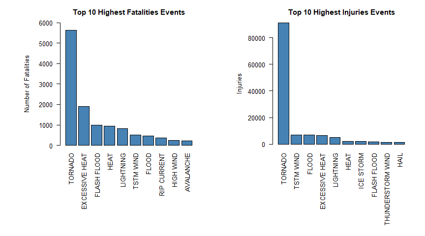

Top 10 Fatalities and Injuries events

```r
par(mfrow = c(1, 2), mar = c(12, 8, 3, 2),  mgp = c(4, 1, 0), cex = 0.8)

with(fatalities_10, barplot(FATALITIES, las = 2, names.arg = EVTYPE, ylab = 'Number of Fatalities', main='Top 10 Highest Fatalities Events', col = 'steelblue', ylim = c(0,6000)))

with(injuries_10, barplot(INJURIES, las = 2, names.arg = EVTYPE, ylab = 'Injuries', main='Top 10 Highest Injuries Events', col = 'steelblue'))
```

We can see that tornado causes the highest fatalities and injuries, over weighted other factors. Overheat is the second largest fatality factor.

## Property and Crop Damages Analysis

### The exponet code issue

From the storm data, we can see there are PROPDMGEXP and CROPDMGEXP fields, which are assumedly corresponding to the PROPDMG and CROPDMG fields prospectively. Unfortunately, we cannot find any information regarding how to decode these exponent fields, neither from NOAA or the course project description. Nevertheless, From the course discussion forum, Johanna Baker points out a possible and reasonable decoding scheme: [How To Handle Exponent Value of PROPDMGEXP and CROPDMGEXP](https://github.com/flyingdisc/RepData_PeerAssessment2/blob/master/how-to-handle-PROPDMGEXP.md). We believe this decoding scheme is mostly correct and use it to continue our analysis further. We also created an exponent decoder in csv format, which can be found in [Exponent Decoder](https://github.com/dsong99/Reproducible-Proj-2.git) for your reference.

### The Exponent Decode

```r
exp_code <- data.frame(
  'Exponent'=factor(c('K','k','M','m','B','b','H','h','0','1','2','3','4','5','6','7','8','+','-','?','')),
  'Multiplier' =c(1000,1000,1000000,1000000,1000000000,1000000000,100,100,1,1,1,1,1,1,1,1,1,1,0,0,0)
)
```

### Property Damages

```r
prop_data <- storm_data[,c('EVTYPE','PROPDMG','PROPDMGEXP')]

unique(prop_data$PROPDMGEXP)
```

```
##  [1] K M   B m + 0 5 6 ? 4 2 3 h 7 H - 1 8
## Levels:  - ? + 0 1 2 3 4 5 6 7 8 B h H K m M
```

Decode the exponent to mutiplier, and find the top 10 properties damage events

```r
prop_data <- merge(x=prop_data, y=exp_code, by.x = 'PROPDMGEXP', by.y = 'Exponent', all.x=TRUE )
prop_data$PROPDMG <- prop_data$PROPDMG * prop_data$Multiplier
prop_damages <- with(prop_data, aggregate(PROPDMG~EVTYPE, FUN=sum, na.action = na.omit))
prop_damages_10 <- prop_damages[order(-prop_damages$PROPDMG),][1:10,]
```

Convert to Billions

```r
prop_damages_10$PROPDMG <- round(prop_damages_10$PROPDMG/1e+9, 3)
prop_damages_10
```

```
##                EVTYPE PROPDMG
## 170             FLOOD 144.658
## 411 HURRICANE/TYPHOON  69.306
## 834           TORNADO  56.937
## 670       STORM SURGE  43.324
## 153       FLASH FLOOD  16.141
## 244              HAIL  15.732
## 402         HURRICANE  11.868
## 848    TROPICAL STORM   7.704
## 972      WINTER STORM   6.688
## 359         HIGH WIND   5.270
```

### Crop Damages

```r
crop_data <- storm_data[,c('EVTYPE','CROPDMG','CROPDMGEXP')]

### check CROPDMGEXP
unique(crop_data$CROPDMGEXP)
```

```
## [1]   M K m B ? 0 k 2
## Levels:  ? 0 2 B k K m M
```

Decode the exponent to mutiplier, and find the top 10 crop damage events

```r
crop_data <- merge(x=crop_data, y=exp_code, by.x = 'CROPDMGEXP', by.y = 'Exponent', all.x=TRUE )
crop_data$CROPDMG <- crop_data$CROPDMG * crop_data$Multiplier

crop_damages <- with(crop_data, aggregate(CROPDMG~EVTYPE, FUN=sum, na.action = na.omit))
crop_damages_10 <- crop_damages[order(-crop_damages$CROPDMG),][1:10,]
crop_damages_10
```

```
##                EVTYPE     CROPDMG
## 95            DROUGHT 13972566000
## 170             FLOOD  5661968450
## 590       RIVER FLOOD  5029459000
## 427         ICE STORM  5022113500
## 244              HAIL  3025954470
## 402         HURRICANE  2741910000
## 411 HURRICANE/TYPHOON  2607872800
## 153       FLASH FLOOD  1421317100
## 140      EXTREME COLD  1292973000
## 212      FROST/FREEZE  1094086000
```

Convert to Billions

```r
crop_damages_10$CROPDMG <- round(crop_damages_10$CROPDMG/1e+9, 3)
crop_damages_10
```

```
##                EVTYPE CROPDMG
## 95            DROUGHT  13.973
## 170             FLOOD   5.662
## 590       RIVER FLOOD   5.029
## 427         ICE STORM   5.022
## 244              HAIL   3.026
## 402         HURRICANE   2.742
## 411 HURRICANE/TYPHOON   2.608
## 153       FLASH FLOOD   1.421
## 140      EXTREME COLD   1.293
## 212      FROST/FREEZE   1.094
```

## Plot the top 10 Property and Crop Damages events

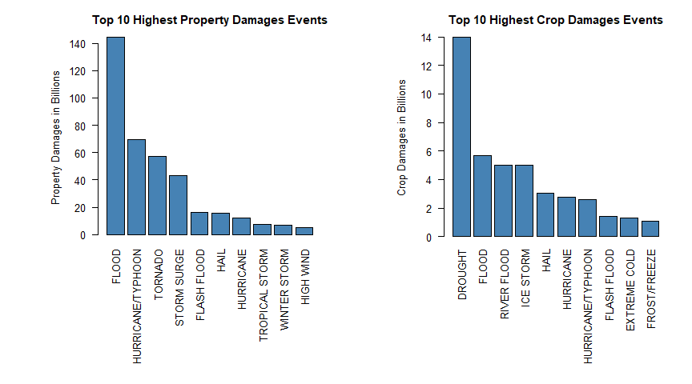

Top 10 Property and Crop Damages events

```r
par(mfrow = c(1, 2), mar = c(12, 8, 3, 2),  mgp = c(3, 1, 0), cex = 0.8)

with(prop_damages_10, barplot(PROPDMG, las = 2, names.arg = EVTYPE, ylab = 'Property Damages in Billions ', main='Top 10 Highest Property Damages Events', col = 'steelblue'))

with(crop_damages_10, barplot(CROPDMG, las = 2, names.arg = EVTYPE, ylab = 'Crop Damages in Billions ', main='Top 10 Highest Crop Damages Events', ylim=c(0, 14),col = 'steelblue'))
```

From Above figure, we can see that floods caused the maximum property damage where as drought caused the maximum crop damage.

# Results and Conclusions

From this study and analysis of the NOAA Storm Database (1950-2011), USA, we can see that tornados caused the maximum number of fatalities and injuries. Surprisingly, overheat is the second largest fatality factor. Floods caused the maximum property damage where as Drought caused the maximum crop damage